# Developments of the base SC13 model for benchmark and MSE considerations

# SPRFMO

South Pacific Regional Fisheries Management Organisation

Jack Mackerel Working Group

Extension of the base (SC13) models for benchmark and MSE considerations

# Abstract

This working paper documents the base SC13 jack mackerel assessment model used for advice under the single-stock and two-stock hypotheses, corresponding to model configurations `h1_1.14` and `h2_1.14`. The paper is intended as a bridge between the full technical annex and a future management strategy evaluation (MSE) framework. Its specific purpose is to describe the Joint Jack Mackerel Model (JJM) as implemented for SC13, identify the principal differences between the two advice models, and define a starting point for evaluating simplified alternatives.

The immediate justification for beginning this work is to avoid carrying into MSE several complicated features that were identified during the [July 2025 MSE workshop](https://sprfmo.github.io/SCW15_report/). These include extensive time-varying selectivity, dynamic reference points that depend on terminal-year model conditions, and projection assumptions that differ from the assumptions used during model fitting. The SC13 base model therefore serves here as the reference assessment formulation from which reduced alternatives can be developed and tested.

# 1 Introduction

The Joint Jack Mackerel Model has been the core age-structured assessment framework used by SPRFMO for jack mackerel over a series of annual updates and technical workshops. In general terms, the model belongs to the class of forward-projecting statistical catch-at-age models developed for fisheries assessment, with estimated population dynamics linked to catch, abundance indices, and composition data through a likelihood-based framework (D. Fournier & Archibald, 1982; Hilborn & Walters, 1992). The broader modelling approach also depends on standard growth and generalized linear model concepts used throughout fisheries science (Bertalanffy, 1957; McCullagh & Nelder, 1989; Nelder & Wedderburn, 1972).

Within the present repository, the SC13 assessment update is represented by model series `1.14`. The file `assessment/README.md` documents the sequence of changes leading to this configuration. In summary, the 2025 assessment update began with a base update to data and model structure (`1.00`) and then proceeded through a sequence of modifications affecting 2025 selectivity, weighting of 2025 age compositions, downweighting of early years of the northern Chile acoustic index, and historical weight-at-age for the Far North fleet. The final advice models were fitted under both stock hypotheses: `h1_1.14` for the single-stock hypothesis and `h2_1.14` for the two-stock hypothesis.

The motivation for documenting these models in a separate working paper is practical. MSE is most useful when the operating model and the management procedure are both transparent, interpretable, and robust to the major uncertainties that matter for management (Butterworth & Punt, 1999; Punt et al., 2016; Siple et al., 2021). The July 2025 MSE workshop concluded that direct transfer of the full SC13 assessment structure into MSE would likely import avoidable complexity. This paper therefore treats `h1_1.14` and `h2_1.14` as the base assessment formulations that must first be documented clearly before any simplification is attempted.

# 2 Materials Used for This Paper

This paper is based on the contents of the assessment directory, with the following files providing the main technical basis for the description:

1. `assessment/README.md`, which documents the model progression to SC13;
2. `doc/annex/annex_text.qmd`, which contains the technical annex narrative;
3. `assessment/R/SC13.rmd`, which records the SC13 update process and the rationale for the final model;
4. `assessment/R/run_projections.R`, which records the projection logic applied to the base model;
5. `assessment/input/1.14.dat`, the common data file used by both stock hypotheses;
6. `assessment/config/h1_1.14.ctl` and `assessment/config/h2_1.14.ctl`, which define the stock-specific control structures;
7. `assessment/results/h1_1.14.rep` and `assessment/results/h2_1.14.rep`, which summarize fitted model outputs and likelihood components.

The objective here is not to reproduce every detail already contained in the annex. Rather, the objective is to extract from those materials a concise but technically defensible description of the SC13 base model for later MSE use.

# 3 General Structure of the JJM Used for SC13

## 3.1 Overview

The annex describes the JJM as an explicitly age-structured forward projection model estimated by maximum likelihood. That places it firmly within the standard family of integrated fisheries assessment models derived from statistical catch-at-age theory (D. Fournier & Archibald, 1982; Schnute & Richards, 1995). In practical implementation, the JJM is also a highly parameterized nonlinear model fitted through AD Model Builder, which is consistent with the long use of ADMB in stock assessment applications (D. A. Fournier et al., 2012).

For SC13, the model is run over years 1970-2025 and ages 1-12. The common data file `assessment/input/1.14.dat` specifies four fishery fleets, seven abundance indices, age-composition observations for multiple fisheries and surveys, length compositions for the Far North fleet, annual catches by fleet, and weight-at-age schedules used in both fishery and survey components. The control files then assign those data to either one or two modeled stocks depending on the hypothesis being fitted.

## 3.2 Data Structure

The SC13 base data set contains four fleets:

1. `N_Chile`;
2. `SC_Chile_PS`;
3. `FarNorth`;
4. `Offshore_Trawl`.

The composition data structure differs by fleet. Age compositions are used for `N_Chile`, `SC_Chile_PS`, and `Offshore_Trawl`, while the `FarNorth` fleet is fitted to length compositions through the modelled growth relationship. The file `assessment/input/1.14.dat` indicates that age-composition observations extend from 1980-2025 for the Chilean fleets and 2015-2025 for the offshore fleet, while length-composition observations are available for the Far North fleet from 1980-2025.

The same data file also includes seven abundance indices:

1. `Chile_AcousCS`;
2. `Chile_AcousN`;
3. `Chile_CPUE`;
4. `DEPM`;
5. `Peru_Acoustic`;
6. `Peru_CPUE`;
7. `Offshore_CPUE`.

This is therefore not a sparse index-only assessment. It is a fully integrated model in which trends in biomass and recruitment are informed simultaneously by catch, multiple abundance indices, and composition data, with the latter carrying substantial influence over selectivity and year-class interpretation. The use of composition data at this level also means that weighting, effective sample size, and selectivity specification become major determinants of fit and inference (Francis, 2011).

## 3.3 Population Dynamics and Observation Model

The annex and control files together indicate a standard age-structured population dynamic framework with stock recruitment, natural mortality, growth, maturity, fleet selectivity, survey selectivity, and catchability. The growth component follows the usual fisheries implementation of the von Bertalanffy growth relationship (Bertalanffy, 1957; Beverton & Holt, 1957). The Far North fleet is modelled through predicted length compositions derived from the age-structured population and the specified growth schedule.

Selectivity is an especially important feature of the SC13 implementation. The annex describes selectivity as non-parametric, fishery-specific, and time-varying. The control files confirm this, showing fleet-specific selectivity structures, annual or block changes by fleet, and selectivity penalties applied to both fisheries and surveys. Time-varying selectivity is a familiar response to changes in fishery behavior and sampling structure, but it is also known to complicate interpretation in catch-at-age assessments (Linton & Bence, 2011).

Catchability is index-specific and includes shared settings across the two hypotheses. The annex further notes that standardized CPUE series include explicit assumptions about efficiency creep, consistent with broader literature on fleet evolution and changing fishing power (Rousseau et al., 2019).

A compact mathematical summary of the core model structure is provided in the appendix so that the main text can stay focused on the SC13 implementation choices rather than on notation.

## 3.4 Reference Points and Projections

The SC13 annex states that `MSY`, `FMSY`, and `BMSY` are calculated internally within the JJM using equilibrium calculations based on terminal-year catch shares, selectivity-at-age, and weights-at-age. Accordingly, these reference points are dynamic rather than fixed. The annex also notes that recent advice has used a ten-year average of model-estimated `BMSY` as the reference biomass quantity for comparison.

The projection scripts in `assessment/R/run_projections.R` add a second layer of structure. Future projections are conducted using fixed terminal selectivity and, for the `.ls` alternatives, a shorter and more conservative recruitment history. This means the advice process combines a fitted assessment model with a somewhat different projection model. That approach is defensible in annual advice, but it is exactly the kind of multi-stage complexity that MSE seeks to simplify and evaluate explicitly (Punt et al., 2016; Siple et al., 2021).

# 4 The SC13 Base Advice Models

## 4.1 Single-Stock Hypothesis: `h1_1.14`

The control file `assessment/config/h1_1.14.ctl` defines the single-stock advice model. It specifies one stock, one recruitment regime, one maturity schedule, one population weight-at-age schedule, and a single natural mortality value of 0.28. The stock recruitment component uses steepness 0.65 and recruitment variability 0.6, with recruitment years 2000-2022 entering the stock recruitment specification.

From a structural point of view, `h1_1.14` is the simpler of the two advice models. All fishery and survey information is interpreted as informing a common population. However, the model still retains considerable complexity because selectivity is allowed to vary over time and because the Far North fleet is represented with annual selectivity changes extending back to 1981. In effect, the single-stock hypothesis avoids stock splitting but compensates with a flexible fleet-history interpretation.

The fitted report file indicates that the model is strongly informed by composition and selectivity components. The total objective function reported in `assessment/results/h1_1.14.rep` is 1323.82, with large contributions from fishery age likelihood, fishery length likelihood, fishery selectivity penalties, index likelihood, and survey age likelihood. This confirms that `h1_1.14` should not be viewed as a simplified baseline in itself. It is already a sophisticated assessment model.

## 4.2 Two-Stock Hypothesis: `h2_1.14`

The control file `assessment/config/h2_1.14.ctl` defines the two-stock advice model. It specifies two stocks, a more complex recruitment assignment, stock-specific biology for the second stock, and different treatment of the Far North observations. In the terminology used in the annex, the two stocks correspond to a southern stock and a far north stock.

The most consequential structural difference lies in recruitment and biological assignment. The two-stock control file specifies `nregbyStock = 1 2`, `RecMatrix = 1 2 3`, and `RegShift = 1999`. In practical terms, this means that the northern component is not represented simply as a second stock with otherwise identical rules. It is represented with a different recruitment structure that includes a regime shift. The recruitment year blocks in the file are 2000-2022, 1970-1996, and 2001-2016 for the three recruitment assignments. The model also assigns a higher natural mortality value to the second stock (0.33), along with a separate maturity schedule and separate population weight-at-age schedule.

The treatment of the Far North fleet also changes substantially under `h2_1.14`. Whereas `h1_1.14` allows a long annual history of selectivity variation for the Far North fleet, `h2_1.14` uses a much simpler regime treatment centered on 2002. This is an important point for later MSE development because the difference between `h1` and `h2` is not purely a question of stock structure. It is partly a difference in how northern observations are interpreted and regularized.

The fitted report file for `h2_1.14` indicates a total objective function of 1194.09. As with the single-stock model, substantial contributions arise from fishery age, fishery length, selectivity penalties, and abundance indices. The lower total objective function relative to `h1_1.14` does not by itself establish superiority, but it does confirm that the two-stock hypothesis is a comparably rich fitted model rather than a stripped-down alternative.

## 4.3 Summary Comparison

Table 1 summarizes the main structural differences between the two SC13 advice models.

| Feature | `h1_1.14` | `h2_1.14` |
| --- | --- | --- |
| Stock hypothesis | Single shared stock | Southern stock plus far north stock |
| Number of modeled stocks | 1 | 2 |
| Data file | `assessment/input/1.14.dat` | `assessment/input/1.14.dat` |
| Natural mortality | 0.28 | 0.28 and 0.33 |
| Maturity schedule | One schedule | Stock-specific schedules |
| Population weight-at-age | One schedule | Stock-specific schedules |
| Recruitment structure | One curve, 2000-2022 | Three assignments with a 1999 regime shift |
| Far North selectivity | Annual variation from 1981 | Simplified regime treatment centered on 2002 |
| Projection horizon | 20 years | 20 years |

The commonality between the two models is therefore greater than their difference in terms of data inputs and overall assessment machinery. The key differences lie in stock allocation, biology, recruitment structure, and the degree of complexity assigned to the northern part of the system.

# 5 Why the SC13 Base Model Is Difficult to Transfer Directly into MSE

The July 2025 MSE workshop concluded that the base assessment should first be documented and then simplified before being used as an MSE operating model. The repository materials support that conclusion.

First, the SC13 base model uses extensive time-varying selectivity. This was increased further in the 2025 assessment to improve fits for the south-central Chile and offshore fleets. Time-varying selectivity may be necessary in annual assessments, but it can make MSE results difficult to interpret because changes in management performance may reflect selectivity specification as much as underlying stock dynamics (Linton & Bence, 2011).

Second, the reference points are dynamic. In the JJM, `BMSY` and `FMSY` depend on terminal-year conditions, especially relative catch shares, selectivity-at-age, and weights-at-age. This makes stock status and advice partly conditional on the most recent fitted model state rather than solely on a stable management benchmark. That is a legitimate assessment choice, but it complicates MSE design because the benchmark itself changes with the assessment outcome.

Third, the projection assumptions differ from the fitting assumptions. The projection scripts show that future calculations rely on fixed selectivity and, in some scenarios, a shortened low-productivity recruitment history. This means that advice is generated from a model in which the fitting phase and the projection phase are intentionally not identical. In MSE, that layering needs to be explicit and deliberate rather than inherited as an assessment convention (Punt et al., 2016; Siple et al., 2021).

Fourth, stock-structure uncertainty is mixed with other differences. The contrast between `h1_1.14` and `h2_1.14` is not just one stock versus two stocks. It also involves different northern selectivity structure, different mortality, different maturity, different population weight-at-age, and different recruitment regime treatment. For MSE, it will be helpful to separate uncertainty about stock structure from uncertainty about how model complexity has been allocated within each hypothesis.

# 6 Proposed Simplified Alternatives

The SC13 base model should therefore be regarded as the reference assessment formulation. Simplified alternatives should be judged according to how much of the essential behavior of the base model they retain while reducing structural complexity that is not strictly necessary for MSE.

A practical first set of alternatives is as follows.

## 6.1 Reduced number of indices

There are three indices in the model that are no longer being conducted and generally fit poorly relative to other data. These included the Central-South acoustic survey, the egg-production index, and the Peruvian acoustic surveys. One sensitivity to omitting these data was considered.

The resulting sensitivity run is represented here by `h1_2.00`, which removes `Chile_AcousCS`, `DEPM`, and `Peru_Acoustic` from the single-stock configuration and also trims the retained `Chile_AcousN` series to years 2000 and later. Relative to `h1_1.14`, this drops 56 index-year observations in total: 13 from `Chile_AcousCS`, 9 from `DEPM`, 28 from `Peru_Acoustic`, and 6 pre-2000 observations from `Chile_AcousN`. It also reduces the fitted parameter vector by 44 parameters, from 1865 in `h1_1.14` to 1821 in `h1_2.00`. This comparison is useful because it isolates a specific simplification of the observation model while leaving the broader single-stock population structure unchanged.

[figure not shown]

Figure 1: Comparison of spawning biomass trajectories from the base single-stock model (`h1_1.14`) and the reduced-index sensitivity (`h1_2.00`).

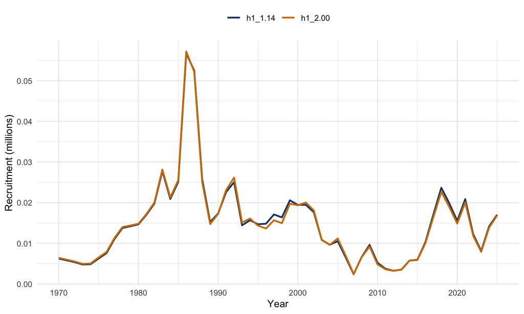

Figure 2: Comparison of recruitment trajectories from the base single-stock model (`h1_1.14`) and the reduced-index sensitivity (`h1_2.00`).

Relative to `h1_1.14`, the reduced-index model leaves the broad historical pattern intact but slightly lowers the terminal objective function, from about 1323.8 in `h1_1.14` to about 1234.7 in `h1_2.00`. Terminal-year spawning biomass uncertainty remains very similar between the two fits, although it is slightly higher in the reduced-index run: the 2025 SSB CV is about 0.125 for `h1_1.14` and about 0.129 for `h1_2.00`. As shown in Figure 1 and Figure 2, the series plots are useful as a first diagnostic of whether the omitted indices were materially changing stock perception or mainly adding noise and additional fitting burden. If the trajectories remain broadly similar, then reducing the index set may be a promising simplification for later MSE work.

## 6.2 Simplified Selectivity Alternatives

One option is to replace long annual selectivity histories with a limited set of blocks for each fleet, for example a historical block, a modern block, and a current block. This preserves the broad evidence that fishery selectivity has changed while avoiding dozens of annual deviations.

## 6.3 Simplified Recruitment Alternatives

A second option is to reduce recruitment complexity by using one recruitment relationship per stock hypothesis, or one per stock under the two-stock model, without additional regime splitting unless that feature is shown to be essential for management performance.

## 6.4 Fixed-Reference-Point Alternatives

A third option is to evaluate MSE performance relative to fixed biomass and harvest-rate benchmarks rather than dynamic reference points estimated from terminal-year conditions. This would make the interpretation of management performance much clearer while still allowing later comparison back to the SC13 assessment convention.

## 6.5 Harmonized Northern Treatment

A fourth option is to harmonize how the Far North observations are treated across the single-stock and two-stock hypotheses. The objective would be to ensure that future comparisons of one-stock and two-stock MSE operating models are driven primarily by stock structure rather than by unrelated differences in selectivity regularization.

# 7 Conclusions

The materials in this assessment directory show that `h1_1.14` and `h2_1.14` are not merely two alternative labels for the same model. They are two distinct but closely related assessment formulations built on a common JJM framework, a common SC13 data set, and a common logic for annual advice. Both models are technically rich and both are appropriate starting points for MSE precisely because they represent the current assessment basis used for advice.

At the same time, both models contain features that make them difficult to carry directly into MSE. The most important of these are time-varying selectivity, dynamic reference points, differing fitting and projection assumptions, and confounding between stock-structure uncertainty and other structural differences. The main conclusion of this working paper is therefore that the SC13 base model should be retained as the benchmark for comparison, but not assumed to be the final operating model for MSE.

The next step is to construct and compare simplified alternatives that remain faithful to the broad SC13 assessment picture while avoiding the complicated issues identified during the July 2025 MSE workshop.

# Appendix: Compact Equation Summary

This appendix gives a compact schematic description of the equations underlying the SC13 Joint Jack Mackerel Model. It is intended to summarize the structure used in this working paper rather than to reproduce every implementation detail of the ADMB code or every option described in the technical annex and user guide.

## 7.1 Notation

Let $s$ index stock, $f$ fishery fleet, $i$ abundance index, $a$ age, $l$ length bin, and $y$ year. Let $A$ denote the plus group age. The main state variable is numbers at age, $N_{s,a,y}$, at the start of year $y$.

The biological and fishery quantities used below are:

1. $M_{s,a}$: natural mortality;
2. $S^{F}_{f,s,a,y}$: fishery selectivity;
3. $S^{I}_{i,s,a,y}$: survey or index selectivity;
4. $w^{\mathrm{pop}}_{s,a,y}$, $w^{\mathrm{catch}}_{f,s,a,y}$, and $w^{I}_{i,s,a,y}$: population, catch, and index weights at age;
5. $m_{s,a}$: maturity at age;
6. $q_i$: catchability for abundance index $i$.

## 7.2 Population Update

For each stock, total mortality at age is

$$Z_{s,a,y} = M_{s,a} + \sum_f F_{f,s,a,y}.$$

Recruitment enters age 1:

$$N_{s,1,y} = R_{s,y}.$$

For ages $a = 1, \ldots, A-2$, cohort survival follows

$$N_{s,a+1,y+1} = N_{s,a,y}\exp(-Z_{s,a,y}).$$

The plus group is updated as

$$\begin{aligned}
N_{s,A,y+1}
&= N_{s,A-1,y}\exp(-Z_{s,A-1,y}) \\
&\quad + N_{s,A,y}\exp(-Z_{s,A,y}).
\end{aligned}$$

Spawning biomass is calculated from mature biomass at the spawning time within the year:

$$SSB_{s,y} =
\sum_a N_{s,a,y}\exp(-\tau Z_{s,a,y}) \, m_{s,a} \, w^{\mathrm{pop}}_{s,a,y}.$$

where $\tau$ is the fraction of annual mortality occurring before spawning.

## 7.3 Stock-Recruitment Relationship

The annex states that the JJM uses a stochastic Beverton-Holt relationship. In compact form,

$$R_{s,y} =
\frac{4h_s R_{0,s} SSB_{s,y-\delta}}
{B_{0,s}(1-h_s) + SSB_{s,y-\delta}(5h_s - 1)}
\exp\left(\varepsilon_{s,y} - \frac{\sigma_{R,s}^2}{2}\right).$$

where $h_s$ is steepness, $R_{0,s}$ is unfished recruitment, $B_{0,s}$ is unfished spawning biomass, $\delta$ is the lag from spawning to recruitment, and $\varepsilon_{s,y}$ is the annual recruitment deviation.

Under `h1_1.14`, this relationship is applied to a single stock with one recruitment regime. Under `h2_1.14`, recruitment is assigned across two stocks with a more complex regime structure, including the 1999 shift described in the control file.

## 7.4 Fishing Mortality and Catch

The annex describes fishing mortality as the product of fleet-specific selectivity and an annual fishing-intensity term. A compact representation is

$$F_{f,s,a,y} = f_{f,y} S^{F}_{f,s,a,y}.$$

where $f_{f,y}$ is the year-specific fleet intensity after incorporating the effort-to-mortality scaling and annual deviations used in the fitted model.

Predicted catch in numbers at age follows the Baranov catch equation:

$$C^{N}_{f,s,a,y} =
N_{s,a,y}
\, \frac{F_{f,s,a,y}}{Z_{s,a,y}}
\, \left(1-\exp(-Z_{s,a,y})\right).$$

Predicted catch in biomass for fleet $f$ is then

$$C^{B}_{f,y} = \sum_s \sum_a C^{N}_{f,s,a,y} \, w^{\mathrm{catch}}_{f,s,a,y}.$$

## 7.5 Abundance Indices

For abundance index $i$, the predicted index is a catchability-scaled vulnerable biomass or abundance quantity:

$$\begin{aligned}
I^{\mathrm{pred}}_{i,y}
&= q_i \sum_s \sum_a
N_{s,a,y}\exp(-\lambda_i Z_{s,a,y}) \\
&\quad \times S^{I}_{i,s,a,y} \, w^{I}_{i,s,a,y}.
\end{aligned}$$

where $\lambda_i$ places the survey or CPUE observation within the year. This expression is schematic because some indices are closer to numbers-at-age and others to biomass, but it captures the model logic used across the SC13 index components.

## 7.6 Age and Length Compositions

Predicted fishery or survey age composition is obtained by normalizing predicted numbers-at-age in the relevant observation:

$$p^{\mathrm{age}}_{g,a,y} =
\frac{n^{\mathrm{pred}}_{g,a,y}}
{\sum_a n^{\mathrm{pred}}_{g,a,y}}.$$

where $g$ denotes the fleet or survey being sampled.

For the Far North fleet, predicted age compositions are converted to predicted length compositions through the growth model:

$$p^{\mathrm{len}}_{f,l,y} = \sum_a p^{\mathrm{age}}_{f,a,y} \, g_{f,l \mid a}.$$

where $g_{f,l \mid a}$ is the probability of a fish of age $a$ being observed in length bin $l$, derived from the von Bertalanffy growth specification used by the model.

## 7.7 Observation Likelihoods

The annex indicates log-normal likelihoods for catches and abundance indices, and multinomial likelihoods for age and length compositions.

For catches and indices, the negative log-likelihood contribution is written schematically as

$$\ell_{\mathrm{LN}} =
\sum_y
\frac{\left[\log(O_y)-\log(P_y)\right]^2}{2\sigma_y^2}.$$

where $O_y$ and $P_y$ are observed and predicted values.

For age or length compositions, with effective sample size $n_{g,y}$,

$$\ell_{\mathrm{mult}} =
-\sum_y n_{g,y} \sum_k o_{g,k,y}\log\left(p_{g,k,y}\right).$$

where $k$ indexes age or length bins, $o_{g,k,y}$ is the observed proportion, and $p_{g,k,y}$ is the predicted proportion.

The SC13 model uses Francis weighting for age-composition effective sample sizes, so the composition likelihood is strongly affected by those externally specified weights.

## 7.8 Objective Function

The full estimation criterion combines data likelihoods, priors, and smoothing penalties:

$$\mathcal{L} =
\ell_{\mathrm{catch}}
+ \ell_{\mathrm{index}}
+ \ell_{\mathrm{age}}
+ \ell_{\mathrm{len}}
+ \ell_{\mathrm{priors}}
+ \ell_{\mathrm{sel}}.$$

The final term, $\ell_{\mathrm{sel}}$, is especially important in SC13 because the model includes extensive penalties on fishery and survey selectivity trajectories to regularize the time-varying non-parametric selectivity schedules.

## 7.9 Dynamic Reference Points

The annex states that the JJM calculates equilibrium reference points internally using terminal-year catch shares, selectivity-at-age, and weights-at-age. In compact form,

$$F_{\mathrm{MSY},y} = \operatorname*{arg\,max}_{F} C^{\mathrm{eq}}_y(F).$$

$$MSY_y = C^{\mathrm{eq}}_y(F_{\mathrm{MSY},y}).$$

$$B_{\mathrm{MSY},y} = B^{\mathrm{eq}}_y(F_{\mathrm{MSY},y}).$$

where the equilibrium yield and biomass functions are conditional on the terminal-year fishery mix and biological schedules. This is why `FMSY`, `MSY`, and `BMSY` vary through time in the SC13 assessment rather than remaining fixed constants.

## References

Bertalanffy, L. von. (1957). Quantitative laws in metabolism and growth. *The Quarterly Review of Biology*, *32*(3), 217–231. https://doi.org/10.1086/401873

Beverton, R. J. H., & Holt, S. J. (1957). *On the dynamics of exploited fish populations* (Vol. 19, p. 533). H. M. Stationery Office.

Butterworth, D. S., & Punt, A. E. (1999). Experiences in the evaluation and implementation of management procedures. *ICES Journal of Marine Science*, *56*(6), 985–998. https://doi.org/10.1006/jmsc.1999.0532

Fournier, D. A., Skaug, H. J., Ancheta, J., Ianelli, J., Magnusson, A., Maunder, M. N., Nielsen, A., & Sibert, J. (2012). AD model builder: Using automatic differentiation for statistical inference of highly parameterized complex nonlinear models. *Optimization Methods and Software*, *27*(2), 233–249. https://doi.org/10.1080/10556788.2011.597854

Fournier, D., & Archibald, C. P. (1982). A general theory for analyzing catch at age data. *Canadian Journal of Fisheries and Aquatic Sciences*, *39*(9), 1195–1207. https://doi.org/10.1139/f82-157

Francis, R. I. C. C. (2011). Data weighting in statistical fisheries stock assessment models. *Canadian Journal of Fisheries and Aquatic Sciences*, *68*(7), 1124–1138. https://doi.org/10.1139/f2011-025

Hilborn, R., & Walters, C. J. (1992). *Quantitative fisheries stock assessment: Choice, dynamics and uncertainty*. Springer. https://doi.org/10.1007/978-1-4615-3598-0

Linton, B. C., & Bence, J. R. (2011). Catch-at-age assessment in the face of time-varying selectivity. *ICES Journal of Marine Science*, *68*(3), 611–625. https://doi.org/10.1093/icesjms/fsq173

McCullagh, P., & Nelder, J. A. (1989). *Generalized linear models* (2nd ed.). Chapman; Hall.

Nelder, J. A., & Wedderburn, R. W. M. (1972). Generalized linear models. *Journal of the Royal Statistical Society. Series A (General)*, *135*(3), 370–384. https://doi.org/10.2307/2344614

Punt, A. E., Butterworth, D. S., Moor, C. L. de, Oliveira, J. A. A. de, & Haddon, M. (2016). Management strategy evaluation: Best practices. *Fish and Fisheries*, *17*(2), 303–334. https://doi.org/10.1111/faf.12104

Rousseau, Y., Watson, R. A., Blanchard, J. L., & Fulton, E. A. (2019). Evolution of global marine fishing fleets and the response of fished resources. *Proceedings of the National Academy of Sciences of the United States of America*, *116*(25), 12238–12243. https://doi.org/10.1073/pnas.1820344116

Schnute, J. T., & Richards, L. J. (1995). The influence of error on population estimates from catch-age models. *Canadian Journal of Fisheries and Aquatic Sciences*, *52*(10), 2063–2077. https://doi.org/10.1139/f95-800

Siple, M. C., Koehn, L. E., Johnson, K. F., Punt, A. E., Canales, T. M., Carpi, P., Moor, C. L. de, Oliveira, J. A. A. de, Gao, J., Jacobsen, N. S., Lam, M. E., Licandeo, R., Lindegren, M., Ma, S., Óskarsson, G. J., Sanchez-Maroño, S., Smoliński, S., Surma, S., Tian, Y., … Zimmermann, F. (2021). Considerations for management strategy evaluation for small pelagic fishes. *Fish and Fisheries*, *22*(6), 1167–1186. https://doi.org/10.1111/faf.12579